# Exploratory Data Analysis & Visualization (EDAV) - HW2

Antonios Kagias

2022-11-05

## 1. queen.csv

```r
songs <- read.csv(file = 'queen.csv')
```

#### Ερώτημα (α)

**Δώστε ένα bar plot όπου να φαίνεται το πλήθος των tracks ανά album.**

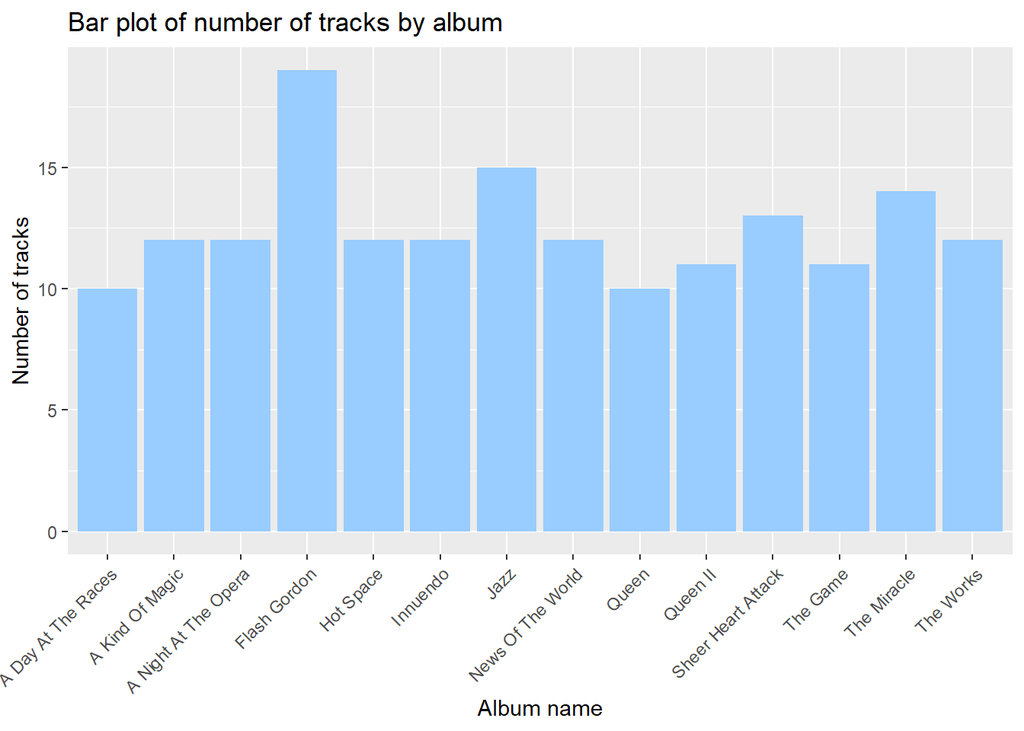

```r
songs %>%
  ggplot(aes(x = album_name)) +
  geom_bar(fill="#99CCFF") +
  theme(axis.text.x = element_text(angle = 45, vjust = 1, hjust = 1)) +
  labs(title = "Bar plot of number of tracks by album",
       x = "Album name",
       y = "Number of tracks")
```

#### Ερώτημα (β)

**Δώστε ένα histogram (με 15 bins) που να δείχνει την κατανομή των τιμών του tempo των tracks. Χρησιμοποιήστε το aesthetic fill για να δείξετε την κατανομή του mode των tracks του κάθε bin.**

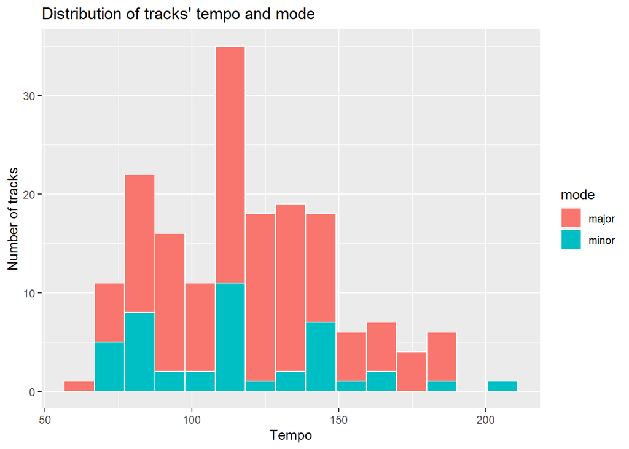

```r
songs %>%
  ggplot(aes(tempo, fill = mode)) +
  geom_histogram(bins = 15, color = "white") +
  labs(title = "Distribution of tracks' tempo and mode",
       x = "Tempo",
       y = "Number of tracks")
```

#### Ερώτημα (γ)

**Δώστε τα boxplots του tempo ανά album.**

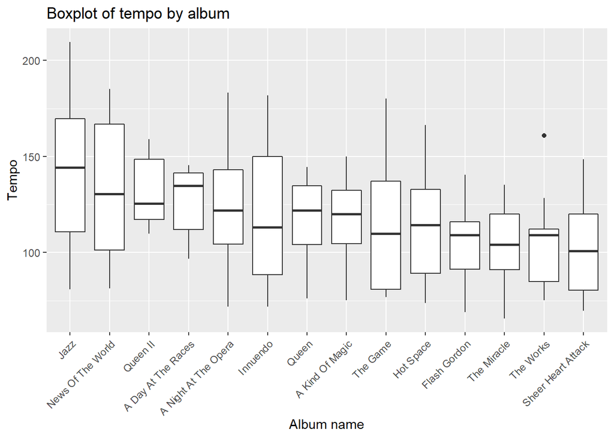

```r
songs %>%
  ggplot(aes(x = reorder(album_name, -tempo), y = tempo)) +
  geom_boxplot() +
  theme(axis.text.x = element_text(angle = 45, vjust = 1, hjust = 1)) +
  labs(title = "Boxplot of tempo by album",
       x = "Album name",
       y = "Tempo")
```

#### Ερώτημα (δ)

**Δώστε ένα faceted scatterplot ως προς το danceability και το energy για κάθε album. Χρησιμοποιήστε το aesthetic size για το tempo.**

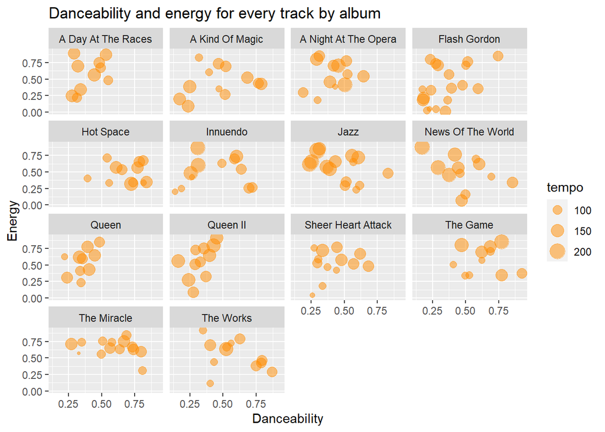

```r
songs %>%
  ggplot(aes(x = danceability, y = energy)) +
  geom_point(aes(size = tempo), alpha = 0.5, position = "jitter", color = "#FF8C00") +
  facet_wrap(~album_name) +
  labs(title = "Danceability and energy for every track by album",
       x = "Danceability",
       y = "Energy")
```

#### Ερώτημα (ε)

**Δώστε άλλα δυο ενδιαφέροντα plots της δικής επιλογής.**

Διάρκεια των tracks ανά album:

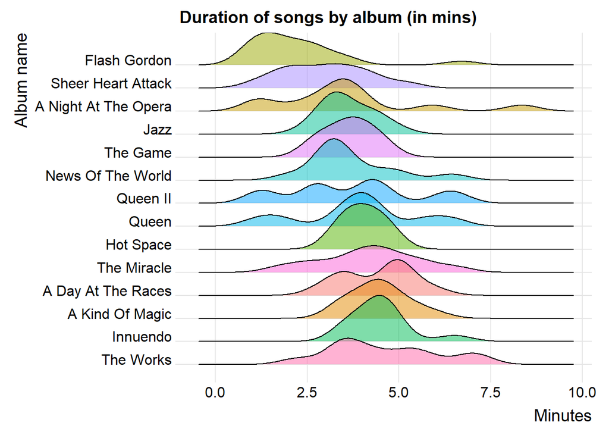

```r
minutes = songs$duration_ms / 60000
songs %>%
  ggplot(aes(x = minutes, y = reorder(album_name, -minutes), fill = album_name)) +
  geom_density_ridges(scale = 2, alpha = 0.5) +
  theme_ridges() +
  labs(title = "Duration of songs by album (in mins)",
       x = "Minutes",
       y = "Album name") +
  theme(legend.position = "none")
```

Μέση δημοτικότητα των tracks ανά album:

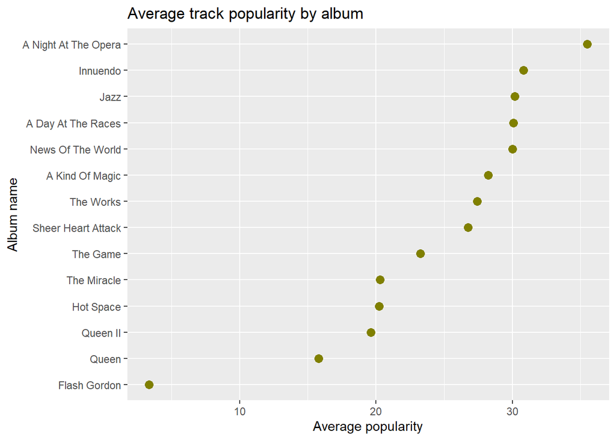

```r
mean_popularity <- group_by(songs, album_name) %>% summarize(m = mean(track_popularity))
mean_popularity %>%
  ggplot(aes(x = m, y = reorder(album_name, m))) +
  geom_point(color = "#808000", size = 3) +
  labs(title = "Average track popularity by album",
       x = "Average popularity",
       y = "Album name")
```

## 2. mcdonalds.csv

```r
borgirs <- read.csv(file = 'mcdonalds.csv')
```

**Το dataset mcdonalds.csv περιέχει για διάφορες χώρες και χρονιές την τιμή του BIG MAC σε τοπικό νόμισμα. Με τη βοήθεια των επιπλέον στηλών (dollar_ex είναι η ισοτιμία του τοπικού νομίσματος με το δολάριο) υπολογίστε τις τιμές του BIG MAC σε US dollars και δώστε ένα scatterplot ως προς το GDP των χωρών και την τιμή του BIG MAC σε US dollars.**

[figure not shown]

```r
price_in_USD = borgirs$local_price / borgirs$dollar_ex
borgirs %>%
  ggplot(aes(x = price_in_USD, y = GDP_dollar)) +
  geom_point(alpha = 0.5, position = "jitter", color = "#008B8B") +
  labs(title = "Scatterplot of Big Mac price in USD and countries' GDP",
       x = "Price in USD",
       y = "GDP in USD")
```